# DataZoo - Applicant Task 2 & 3

## DataZoo - Applicant Task 2

### Candidate: Jose David Perez

#### Importing required libraries

```python
import pandas as pd
import matplotlib.pyplot as plt

%matplotlib inline
plt.rcParams.update({'figure.figsize': (10, 5), 'figure.dpi': 120})
```

```python
series = pd.read_parquet('time_series_set.parquet', engine='pyarrow')
```

```python
series.head()
```

| key_1 | key_2 | date | target |
| --- | --- | --- | --- |
| key_1_0 | 5414270 | 2018-03-18 | 0.086695 |
|  | 2387740 | 2018-03-19 | 0.264376 |
|  | 790880 | 2018-03-20 | 0.273167 |
|  | 9801650 | 2018-03-21 | 1.024270 |
|  | 4986800 | 2018-03-22 | 0.903192 |

```python
series.info()
```

```
<class 'pandas.core.frame.DataFrame'>
MultiIndex: 8732924 entries, ('key_1_0', '5414270', Timestamp('2018-03-18 00:00:00')) to ('key_1_39996', '329699999', Timestamp('2018-12-31 00:00:00'))
Data columns (total 1 columns):
 #   Column  Dtype
---  ------  -----
 0   target  float64
dtypes: float64(1)
memory usage: 458.5+ MB
```

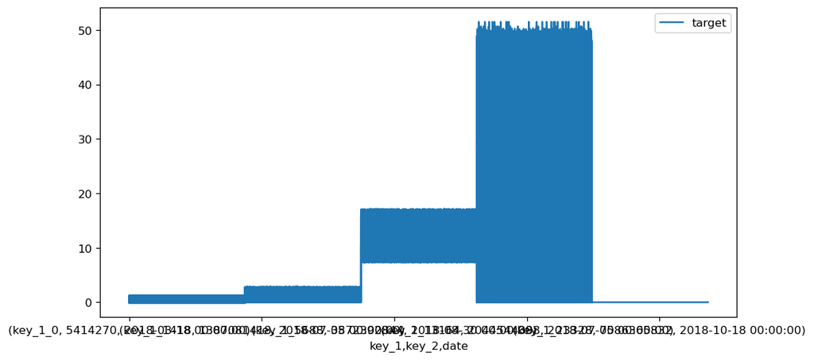

```python
series.plot()
```

### Task 2 - Questions

#### What would your strategy for getting insights in such a "big" time series set?

Decompose data with different methods to enable easy analysis of the time series, you can start detecting patterns with seasonality, stationary series, etc.

#### We used the long format for our time series set. A wide format would be also possible. What are the advantages of these two types of time series representation?

In wide format, categorical data is always grouped. You can think of it as a summary of long data. It is easier to read and interpret as compared to long format. In long vertical format, every row represents an observation belonging to a particular category.

### Task 3 - Questions

#### Loss functions measure accuracy/performance and define "optimal" point forecasts. RMSE, MAPE, and MAD are some standard metrics used in forecasting.

#### Could you explain advantages / disadvantages of these three metrics?

1. RMSE serves as an heuristic for training models or to evaluate the accuracy of trained models, and this accuracy depends totally of what you're looking for in your data.
2. MAPE serves as an accuracy indicator but it can be poor because each error is divided by the demand, so it is skewed.
3. MAD serves as very good KPI to measure forecast accuracy, mean of the absolute error. But it's not scaled to the average demand.